# Data Analyst Entry Test

DSC Team - VIB

Please submit your answer via [this link](http://form-timer.com/start/3b8945e9). It is important to note that this is timed technical test. Try your best!

# SQL Query 40%

Prepare SQL Script to calculate transition matrix with data from [this link](https://docs.google.com/spreadsheets/d/1vVGJziFmCnpS6-ePgc6ZpjVlPLrX9QMo_8gBJTeNy-k/edit?usp=sharing) as per below template.

- Roll back: Loans that have DPD group lower than started with (e.g. Loans that are in B1 as of 201906 and move back to B0 as of 201907)
- Stabilize: Loans that have DPD group that is the same as started with (e.g. Loans that are in B1 as of 201906 and stay the same as B1 as of 201907)
- Roll forward: Loans that have DPD group higher than started with (e.g. Loans that are in B1 as of 201906 and move to B2 as of 201907)

```
## Month  | DPDGroup | Roll back    | Stabilize |   Roll forward|
## 201906 |   B0     |              |       97% |           3%  |
## 201906 |   B1     |              |           |               |
## 201906 |   B2     |              |           |               |
## 201906 |   B3     |              |           |               |
```

# Statistical thinking 20%

## Question 1: Probability thinking

Defaulting on a loan means failing to pay it back on time. The default rate among VIB clients on their personal loans is 1%. As a project you develop a test to predict which client will default. Your test is good but not perfect. It gives 4% false positives, i.e. predicting a customer will default who in fact will not. If has a 0% false negative rate, i.e. predicting a customer won’t default who in fact will.

1. Suppose a random customer tests positive. What is the probability that he will truly default?
2. Suppose your boss offers to bet you the customer in part (1) won’t default. He wants you to pay him $100 if the customer doesn’t default and he’ll pay you $400 if the customer does default. Is this a good bet for you to take?

## Question 2: Simulation

Data is collected on the time between arrivals of customers at a branch of VIB. We collect a data set of size 45 with sample mean $\bar{x}$ = 5.0 and sample standard deviation $s$ = 4.0. By bootstrapping, we generate 500 values for the differences $\delta^* = \bar{x}^* - \bar{x}$. The smallest and largest 150 are written in non-decreasing order in `smallest` and `largest` variables. Use this data to find an 80% bootstrap confidence interval for $\mu$.

# Statistical programming: Python 20%

2. The `data` variable contains the information of Brain size. We have imported `pandas` as `pd` and `numpy` as `np` already for you.

Please reproduce the following image.

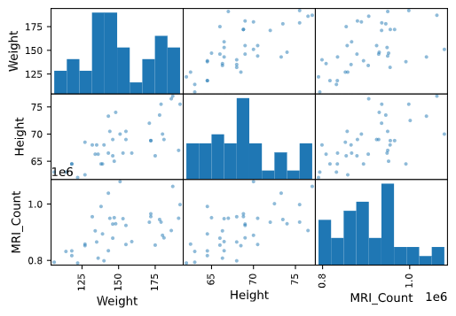

3. The IQ metrics are unimodal.
4. In linear algebra, we use matrix operators to compute beta matrix for multiple linear regression. With pandas and numpy only, return the list of beta.

# Machine learning 20%

From following pseudo code of k-nearest neighbors for classification, please convert it into Python code. Using only `numpy` as `np`.

```sql
for everyPoint in dataSet:
  Calculate distance between observation X and the current point
  Sort the distances in increasing order
  Take k items with lowest distances to observation X
  Find the majority class among these items
  Return the majority class as our prediction for the class of observation X
```